# Noise estimation & denoising

Noise estimation and denoising are important steps in signal processing, especially in the context of structural vibration analysis. Noise can obscure the underlying signal, making it difficult to extract meaningful information. For instance, in inverse problems, noise can significantly affects the accuracy of the estimated solution when the system is ill-posed. Another example is Kalman filtering for which the noise covariance matrix is a key parameter.

`StructuralVibration.jl` provides a set of tools for estimating noise in signals and for denoising them. The implemented methods can be applied to real or complex signals.

Here, it is assumed that the noise is additive and Gaussian. This means that the noisy signal on a sensor $i$, $\mathbf{y}_i$, can thus be modeled as the sum of a noise-free signal $\mathbf{x}_i$ and a noise term $\mathbf{n}_i$:
$$\mathbf{y}_i = \mathbf{x}_i + \mathbf{n}_i,$$
where $\mathbf{n}_i$ is a zero-mean Gaussian noise with covariance matrix $\mathbf{R}_i$. A common assumption is that the noise covariance matrix is isotropic, implying that:
$$\mathbf{R}_i = \sigma_i^2 \mathbf{I}_n,$$
where $\sigma_i^2$ is the noise variance on the channel $i$ and $\mathbf{I}$ is the identity matrix of size $n$ (the number of samples in the signal).

## 1 Noise estimation

Noise estimation is the process of quantifying the level of noise present in a signal. This can be done using various methods, such as statistical analysis, spectral analysis, or model-based approaches. In `StructuralVibration.jl`, two main strategies are available for noise estimation:

- Regularization-based : These methods involve the resolution of an optimization problem.
- Filtering-based : These methods are based on a careful analysis of the statistics of a noisy signal and do not involve optimization.

### 1.1 Estimation methods

#### 1.1.1 Regularization-based noise estimation

Regularization-based noise estimation methods involve solving an optimization problem to estimate the noise variance associated to each measurement channel. The optimization problem is typically formulated as a minimization of a cost function that balances the fidelity to the data and a regularization term.

From a general perspective, the denoising problem can be formulated as:
$$\widehat{\mathbf{x}}_i = \underset{\mathbf{x}_i}{\text{argmin}} \Vert \mathbf{y}_i - \mathbf{x}_i \Vert_2^2 + \lambda \Vert \mathbf{D} \mathbf{x}_i \Vert_2^2,$$
where $\mathbf{D}$ is generally the second order finite difference operator, $\lambda$ is a regularization parameter.

The solution of the previous optimization problem is given by:
$$\widehat{\mathbf{x}}_i = \left( \mathbf{I} + \lambda \mathbf{D}^\mathsf{T} \mathbf{D} \right)^{-1} \mathbf{y}_i,$$

A classical estimator of the noise variance is the biased sample variance given by:
$$\widehat{\sigma}_i^2 = \frac{1}{n} \Vert \mathbf{y}_i - \widehat{\mathbf{x}}_i \Vert_2^2.$$

The main point here is to find an appropriate regularization parameter $\lambda$. In the literature, several methods have been proposed to estimate the regularization parameter. In this package, the following methods are implemented:

- Generalized Cross Validation (GCV)[^1]
- L-curve method[^2]

**Note**

In practice, this estimator can be computed without computing the denoised signal $\widehat{\mathbf{x}}_i$ explicitly. To do so, the implementation makes use of the discrete cosine transform (DCT).

#### 1.1.2 Filtering-based noise estimation

Heuristic-based noise estimation methods are based on a careful analysis of the statistics of a noisy signal and often rely on the assumption that the noise is Gaussian. These methods do not involve optimization and are typically faster than regularization-based methods. They can be used to estimate the noise variance directly from the noisy signal. `StructuralVibration.jl` implements the method proposed John D’Errico in the Matlab function `estimatenoise.m`[^3]

### 1.2 API

**Data types**

**GCVEst**

```
GCVEst
```

Generalized Cross-Validation (GCV) noise estimation

This method has been proposed by Garcia in [1]

**Fields**

- `nothing`

**Reference**

[1] Garcia, D. (2010). Robust smoothing of gridded data in one and higher dimensions with missing values. Computational Statistics and Data Analysis, 54(5), 1167-1178

**LCurveEst**

```
LCurveEst
```

L-curve noise estimation

This method is based on the method proposed by Hansen in [1]

**Fields**

- `nothing`

**Reference**

[1] Hansen, P. C. (1999). The L-curve and its use in the numerical treatment of inverse problems. Computational Inverse Problems in Electrocardiology, 119-142

**DerricoEst**

```
DerricoEst
```

D'Errico noise estimation

This method has been proposed by John D'Errico in [1]

**Fields**

- `nothing`

**Reference**

[1] John D'Errico (2023). Estimatenoise, MATLAB Central File Exchange. Retrieved December 7, 2023. (https://www.mathworks.com/matlabcentral/fileexchange/16683-estimatenoise)

**Related function**

**varest**

```
varest(x, method::NoiseEstimation; batch_size = 0, summary = mean)
varest(x; batch_size = 0, summary = mean)
```

Estimates the noise variance of a signal `x` using a given method

**Inputs**

- `x`: Signal

- `method`: Noise estimation method

  - `BayesianEst`: Bayesian noise estimation (To be implemented)

  - `GCVEst`: Generalized Cross-Validation (GCV) noise estimation

  - `LCurveEst`: L-curve noise estimation

  - `DerricoEst`: D'Errico noise estimation (default)

- `batch_size::Int`: Batch size for batch processing (default = 0)

- `summary`: Summary function for batch processing (default = mean)

**Output**

- `noisevar`: Noise variance - Vector{Real}

### 1.3 Example

```julia
using Statistics

# Beam definition
L = 1.
b = 3e-2
h = 1e-2
E = 2.1e11
ρ = 7850.
ξn = 1e-2
S = b*h
Iz = b*h^3/12.

beam = Beam(L, S, Iz, E, ρ)

# Measurement mesh
Δx = 5e-2
Npoint = 20
Xm = LinRange(Δx, L - Δx, Npoint)

# Modes calculation
ωn, kn = modefreq(beam, 2000.)
ϕm = modeshape(beam, kn, Xm)
ϕe = modeshape(beam, kn, Xm[13])

# Modal model
Kn, Mn, Cn = modal_matrices(ωn, ξn)

# Excitation
tmax = 0.5
nt = 10_000
t = LinRange(0., tmax, nt)

harmo = SineWave(1e4, 0., tmax, 2π*10.)
F = excitation(harmo, t)
Fn = ϕe'*F'

# Solution calculation
u0 = (zeros(length(ωn)), zeros(length(ωn)))
prob = DirectTimeProblem(Kn, Mn, Cn, Fn, u0, t)
u = ϕm*solve(prob).u

# Signal corruption - Additive Gaussian White Noise
SNR_ref = 25.
y = agwn(u, SNR_ref)

# Variance estimation - Average over all channels
v1 = varest(y, GCVEst())
SNR_est1 = mean(estimated_SNR(y, v1))

v2 = varest(y, LCurveEst())
SNR_est2 = mean(estimated_SNR(y, v2))

v3 = varest(y, DerricoEst())
SNR_est3 = mean(estimated_SNR(y, v3))
```

Noise variance estimation

| Reference | GCV | L-curve | D'Errico |
| --- | --- | --- | --- |
| 25.0 dB | 25.16 dB | 25.1 dB | 25.05 dB |

## 2 Signal denoising

Signal denoising is the process of removing noise from a signal to recover the underlying clean signal. This can be done using various methods, such as filtering, wavelet transforms, or model-based approaches. In `StructuralVibration.jl`, the denoising process is typically performed using the same methods as those used for noise estimation. As for noise estimation, the proposed methods can be applied to real or complex signals.

### 2.1 Denoising methods

`StructuralVibration.jl` proposes two main methods for denoising signals:

- Regularization-based denoising: This method involves solving an optimization problem to estimate the noise-free signal. The optimization problem is typically formulated as a minimization of a cost function that balances the fidelity to the data and a regularization term.
- Filtering-based denoising: This method is based on the implementation of a Kalman filter, which is a recursive algorithm that estimates the state of a dynamic system from a series of noisy measurements.

#### 2.1.1 Regularization-based denoising

Regularization-based denoising consists in solving the minimization problem defined in Section 1.1.1. This implies a proper estimation of the regularization parameter $\lambda$. Similar to the noise estimation process, two methods are available for estimating the regularization parameter, namely GCV and L-curve methods.

#### 2.1.2 Filtering-based denoising

As stated above, filtering-based denoising is based on the implementation of a Kalman filter. For denoising problems, the Kalman filter is based on the following state-space model:
$$\begin{cases}
\mathbf{x}_{k+1} = \mathbf{x}_k + \mathbf{w}_k \\
\mathbf{y}_k = \mathbf{x}_k + \mathbf{n}_k
\end{cases},$$
where $\mathbf{x}_k$ is the state vector (clean signal) at time $k$, $\mathbf{y}_k$ is the measurement vector at time $k$, $\mathbf{w}_k$ is the process noise, and $\mathbf{n}_k$ is the measurement noise. The process noise is assumed to be zero-mean Gaussian with constant covariance matrix $\mathbf{Q}$, and the measurement noise is assumed to be zero-mean Gaussian with constant covariance matrix $\mathbf{R}$.

Practically, a Kalman filter is implemented in two steps:

1. **Prediction step**: The state vector and its covariance matrix are predicted based on the knowledge of the solution at the previous step.
   $$\begin{align*}
   \widetilde{\mathbf{x}}_{k} &= \widehat{\mathbf{x}}_{k-1} \\
   \widetilde{\mathbf{P}}_{k} &= \widehat{\mathbf{P}}_{k-1} + \mathbf{Q}
   \end{align*},$$
   where $\widetilde{\mathbf{x}}_{k}$ is the predicted state vector, $\widehat{\mathbf{x}}_{k-1}$ is the estimated state vector at step $k-1$, $\widetilde{\mathbf{P}}_{k}$ is the predicted covariance matrix, and $\widehat{\mathbf{P}}_{k-1}$ is the estimated covariance matrix at step $k-1$.
2. **Update step**: The state vector and its covariance matrix are updated based on the measurement at the current step.
   $$\begin{align*}
   \mathbf{i}_k &= \mathbf{y}_k - \widetilde{\mathbf{x}}_{k} \\
   \mathbf{S}_k &= \widetilde{\mathbf{P}}_{k} + \mathbf{R} \\
   \mathbf{K}_{k} &= \widetilde{\mathbf{P}}_{k} \mathbf{S}_k^{-1} \\
   \widehat{\mathbf{x}}_{k} &= \widetilde{\mathbf{x}}_{k} + \mathbf{K}_{k} \mathbf{i}_k \\
   \widehat{\mathbf{P}}_{k} &= \left( \mathbf{I} - \mathbf{K}_{k}\right) \widetilde{\mathbf{P}}_{k}
   \end{align*},$$
   where $\widehat{\mathbf{x}}_{k}$ is the updated state vector, $\widehat{\mathbf{P}}_{k}$ is the updated covariance matrix and $\mathbf{K}_{k}$ is the Kalman gain, $\mathbf{i}_k$ is the innovation vector and $\mathbf{S}_k$ is the innovation covariance matrix.

For a successful denoising process, the Kalman filter requires a proper tuning of the noise covariance matrices $\mathbf{Q}$ and $\mathbf{R}$ as wel as a proper initialization of the state vector and its covariance matrix.

Here, the measurement noise covariance matrix $\mathbf{R}$ is estimated using the methods described in the previous section. The process noise covariance matrix $\mathbf{Q}$ is assumed to be isotropic and its variance $\sigma_x^2$ results from the resolution of the following optimization problem:
$$\widehat{\sigma}_x^2 = \underset{\sigma_x^2}{\text{argmin}} \sum_{i = 1}^N \left[\log|\mathbf{S}_k| + \mathbf{i}_k^\mathsf{T}\mathbf{S}_k^{-1}\mathbf{i}_k\right],$$
where $N$ is the length of the measurement sequence.

In addition to the filtering step, a smoothing step can be added. In the present case, a Rauch-Tung-Striebel (RTS) smoother is used. From a practical point of view, the RTS smoother is implemented as a post-processing step that uses the Kalman filter output to improve the estimate of the state vector. The RTS smoother is based on the following equations:
$$\begin{align*}
\widehat{\mathbf{x}}_k^s &= \widehat{\mathbf{x}}_k + \mathbf{K}_k \left( \widehat{\mathbf{x}}_{k+1}^s - \widehat{\mathbf{x}}_k \right) \\
\widehat{\mathbf{P}}_k^s &= \widehat{\mathbf{P}}_k + \mathbf{K}_k \left( \widehat{\mathbf{P}}_{k+1}^s - \widehat{\mathbf{P}}_k \right) \mathbf{K}_k^\mathsf{T} \\
\mathbf{K}_k &= \widehat{\mathbf{P}}_k (\widehat{\mathbf{P}}_k + \mathbf{Q})^{-1} \\
\end{align*},$$
where $\widehat{\mathbf{x}}_k^s$ is the smoothed state vector, $\widehat{\mathbf{P}}_k^s$ is the smoothed covariance matrix, and $\mathbf{K}_k$ is the Kalman gain.

### 2.2 API

**Data types**

**GCVDenoising**

```
GCVDenoising()
```

Regularization-based denoising method using the GCV method for estimating the regularization parameter

**Fields**

- `nothing`

**Reference**

[1] Garcia, D. (2010). Robust smoothing of gridded data in one and higher dimensions with missing values. Computational Statistics and Data Analysis, 54(5), 1167-1178

**LCurveDenoising**

```
LCurveDenoising()
```

Regularization-based denoising method using the L-curve method for estimating the regularization parameter

**Fields**

- `nothing`

**Reference**

[1] Hansen, P. C. (1999). The L-curve and its use in the numerical treatment of inverse problems. Computational Inverse Problems in Electrocardiology, 119-142

**KalmanDenoising**

```
KalmanDenoising(; rts = false)
```

Kalman filter denoising method

**Fields**

- `rts`: Flag to enable the Rauch-Tung-Striebel smoother

**Related function**

**denoising**

```
denoising(y::AbstractArray, alg)
```

Denoises a signal `y`

**Inputs**

- `y`: Noisy signal

- `alg`: Denoising method

  - `BayesDenoising`: Bayesian Regularization denoising method (to be implemented)

  - `GCVDenoising`: GCV denoising method

  - `LCurveDenoising`: L-curve denoising method

  - `KalmanDenoising`: Kalman filter denoising method

**Output**

- `x`: Denoised signal

### 2.3 Example

```julia
# Beam definition
L = 1.
b = 3e-2
h = 1e-2
E = 2.1e11
ρ = 7850.
ξn = 1e-2
S = b*h
Iz = b*h^3/12.

beam = Beam(L, S, Iz, E, ρ)

# Measurement mesh
Δx = 5e-2
Npoint = 20
Xm = LinRange(Δx, L - Δx, Npoint)

# Modes calculation
ωn, kn = modefreq(beam, 2000.)
ϕm = modeshape(beam, kn, Xm)
ϕe = modeshape(beam, kn, Xm[13])

# Modal model
Kn, Mn, Cn = modal_matrices(ωn, ξn)

# Problem definition & solution
tmax = 0.1
nt = 5_000
t = LinRange(0., tmax, nt)

harmo = SineWave(1e4, 0., tmax, 2π*10.)
F = excitation(harmo, t)
Fn = ϕe'*F'

u0 = (zeros(length(ωn)), zeros(length(ωn)))
prob = DirectTimeProblem(Kn, Mn, Cn, Fn, u0, t)
sol = solve(prob)

u = ϕm*sol.u

# Gaussian White Noise
snr_dB = 10.
y = agwn(u, snr_dB)

# Regularization denoising
yc_gcv = denoising(y, GCVDenoising())
yc_lcurve = denoising(y, LCurveDenoising())

# Kalman denoising
yc_kalman = denoising(y, KalmanDenoising())
yc_rts = denoising(y, KalmanDenoising(rts = true))
```

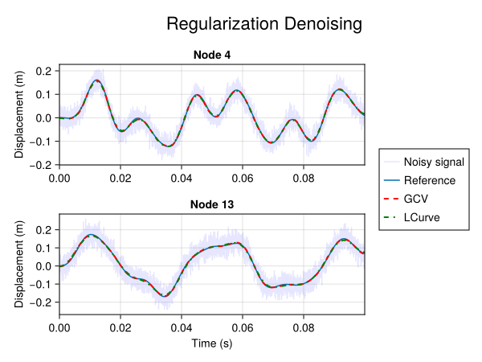

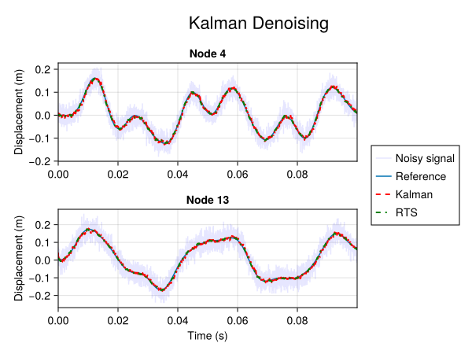

## Footnotes

[^1]: D. Garcia. “Robust smoothing of gridded data in one and higher dimensions with missing values”. Computational Statistics & Data Analysis, 54(5), pp. 1167-1178, 2010.
[^2]: P. C. Hansen. “The L-curve and its use in the numerical treatment of inverse problems”. Computational Inverse Problems in Electrocardiology, pp. 119-142, 2001.
[^3]: John D’Errico. “Estimatenoise”, MATLAB Central File Exchange. Retrieved December 7, 2023. [Link](https://www.mathworks.com/matlabcentral/fileexchange/16683-estimatenoise)